# Kalboard 360 Online Learning

## Data Introduction

The data is taken from the website “kaggle.com” which provides access to many different data sets, one of which, including this data set of an online learning service called ‘Kalboard 360’. This service measures many different metrics as the students learn through a variety of online classes. There are 480 observations in this data set.

Variables:

```
- ParentschoolSatisfaction
- AnnouncementsView
- Discussion
- raisedhands
- Class
- StudentAbsenceDays
```

ParentschoolSatisfaction - The satisfaction of the parent of the learning service measured with response ‘yes’, ‘no’.

AnnouncementsView - A measure of how many times the student views class announcements measured 0-100

Discussion - The amount of times the student participates in discussion measured 0-100

raisedhands - The number of times a student raises their hand. 0-100

StudentAbsenceDays - The number of days a student is absent. This is measured by two groupings ‘Under-7’, ‘Above-7’

Class - A categorical grouping of the students based on their performance in the class. Low-Level: interval includes values from 0 to 69, Middle-Level: interval includes values from 70 to 89, High-Level: interval includes values from 90-100.

Conceptual Questions:

- Does the amount of participation in the virtual classroom effect the amount of times a student will examine announcements?
- Does greater student involvement relate to greater parent satisfaction of the program?

## Linear Regression

```
##
## Call:
## lm(formula = AnnouncementsView ~ raisedhands + Discussion + Class,
##     data = ProjectData)
##
## Residuals:
##     Min      1Q  Median      3Q     Max
## -66.449 -12.659  -0.693  13.189  62.081
##
## Coefficients:
##              Estimate Std. Error t value Pr(>|t|)
## (Intercept)  14.72550    3.37489   4.363 1.57e-05 ***
## raisedhands   0.39701    0.03846  10.323  < 2e-16 ***
## Discussion    0.20032    0.03415   5.866 8.38e-09 ***
## ClassL      -12.03283    3.12383  -3.852 0.000133 ***
## ClassM       -1.96466    2.24984  -0.873 0.382971
## ---
## Signif. codes:  0 '***' 0.001 '**' 0.01 '*' 0.05 '.' 0.1 ' ' 1
##
## Residual standard error: 19.28 on 475 degrees of freedom
## Multiple R-squared:  0.4794, Adjusted R-squared:  0.4751
## F-statistic: 109.4 on 4 and 475 DF,  p-value: < 2.2e-16
```

Interpretation of Coefficients: Holding all other variables constant increasing raisedhands by one on average increases the announcement view by 0.39701. The same is respectively true for Discussion, on average increasing announcement views by 0.20032, and class being == ‘low’ on average decreasing announcement views by -12.03283. As well as class == ‘med’ on average decreasing it by -1.96466.

In relation to the first conceptual question as to whether participation affects the average announcement views. It appears that both forms of participation have minimal positive effects on the announcement views. The variable Class, however appears to have a much greater impact on announcementviews. More specifically ClassM is not significant which makes sense as those are students that are passing the class. ClassL is only students with failing grades and so it would make sense for this to drastically effect the average announcement views.When looking at the adjusted R^2 of the model we can see that the model explains 47.51 % of the variation in the outcome.

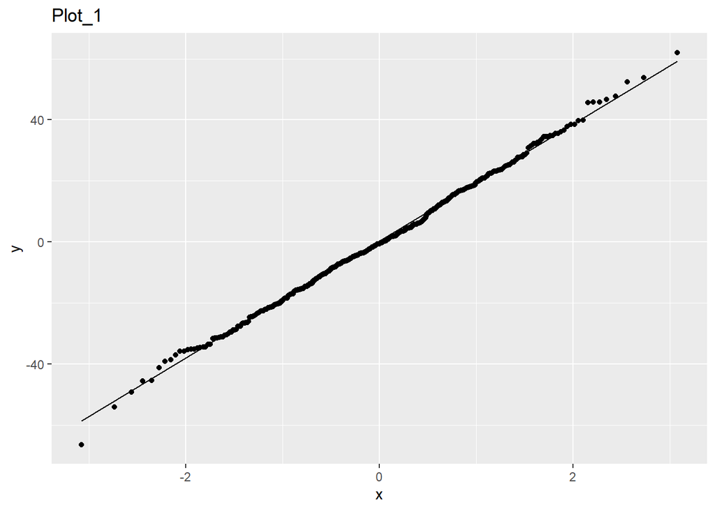

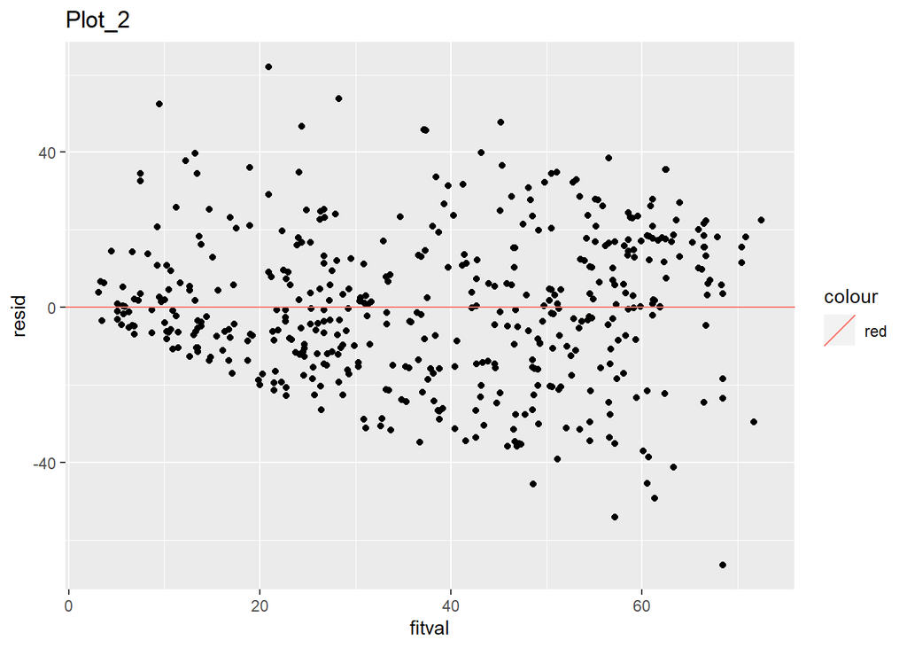

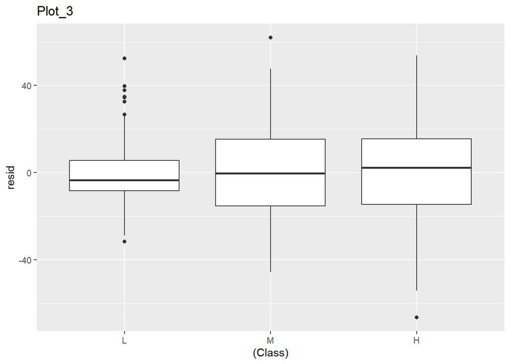

The data appears on the qq-plot (Plot_1) to pass the assumption of linearity however, upon further investigation in (Plot_2) when the residuals are plotted against the fitted values you can see that the data vaguely resembles a cone opening to the right. Ideally the data is randomly scattered around zero. This however is not the case. Taking a closer look in (Plot_3) of box plots across the categorical variables of ‘class’ we can see the distribution between ‘ClassH’,‘ClassM’ and ‘ClassL’. The variance of ‘ClassL’ differes greatly from the other two classes leading to a failure of the assumption of homoscedasticity. This is indicative of a limitation of the model as the model will struggle to provide precise predictions for the students with class performances of ‘M’ or ‘H’ as the residual values are much greater.

## Logistic Regression

We are attempting to answer the second conceptual question with the logistic regression. Does greater student involvement predict parent satisfaction with the program. Parent satisfaction is a binary variable Student involvement in this case is indicated by raised hands and discussion in the class.

```
##
## Call:
## glm(formula = Satisfaction ~ raisedhands + Discussion, family = binomial,
##     data = ProjectDataLOG)
##
## Deviance Residuals:
##     Min       1Q   Median       3Q      Max
## -1.9197  -1.1066   0.7034   0.9126   1.4756
##
## Coefficients:
##              Estimate Std. Error z value Pr(>|z|)
## (Intercept) -0.385521   0.202363  -1.905   0.0568 .
## raisedhands  0.022021   0.003521   6.253 4.02e-10 ***
## Discussion  -0.003659   0.003807  -0.961   0.3365
## ---
## Signif. codes:  0 '***' 0.001 '**' 0.01 '*' 0.05 '.' 0.1 ' ' 1
##
## (Dispersion parameter for binomial family taken to be 1)
##
##     Null deviance: 642.71  on 479  degrees of freedom
## Residual deviance: 598.30  on 477  degrees of freedom
## AIC: 604.3
##
## Number of Fisher Scoring iterations: 4
```

```
##          n
## 1 75.68493
```

```
##         n
## 1 46.2766
```

```
##   PANEL group       AUC
## 1     1    -1 0.6098076
```

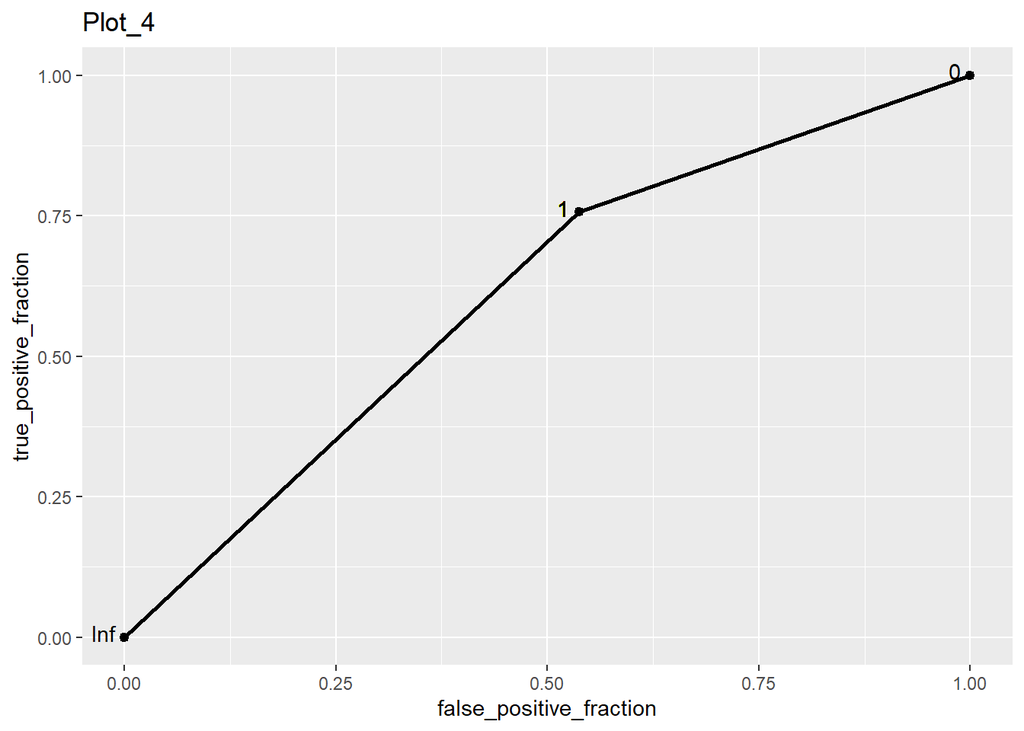

The sensitivity of the model is 75.68493 % and the specificity is 46.2766 % The AUC is 0.6098076. Just by looking at the ROC curve we can see that this model does not do that great of a job of predicting parentschoolSatisfaction but does to some extent. The variable Discussion does not appear to be a significant predictor, While it appears most of the explaining is done by raisedhands. This would leave me to believe that raisedhands could have some play in effecting ParentschoolSatisfaction.

## Logistic Regression with Training Test Split.

```
##
## Call:
## glm(formula = Satisfaction ~ raisedhands + Discussion, family = binomial,
##     data = data_train)
##
## Deviance Residuals:
##     Min       1Q   Median       3Q      Max
## -1.8645  -1.1586   0.7344   0.9198   1.4202
##
## Coefficients:
##              Estimate Std. Error z value Pr(>|z|)
## (Intercept) -0.362017   0.243005  -1.490    0.136
## raisedhands  0.020030   0.004198   4.772 1.82e-06 ***
## Discussion  -0.002408   0.004675  -0.515    0.606
## ---
## Signif. codes:  0 '***' 0.001 '**' 0.01 '*' 0.05 '.' 0.1 ' ' 1
##
## (Dispersion parameter for binomial family taken to be 1)
##
##     Null deviance: 449.36  on 335  degrees of freedom
## Residual deviance: 423.18  on 333  degrees of freedom
## AIC: 429.18
##
## Number of Fisher Scoring iterations: 4
```

```
##          n
## 1 77.01149
```

```
##          n
## 1 56.14035
```

```
##   PANEL group       AUC
## 1     1    -1 0.6657592
```

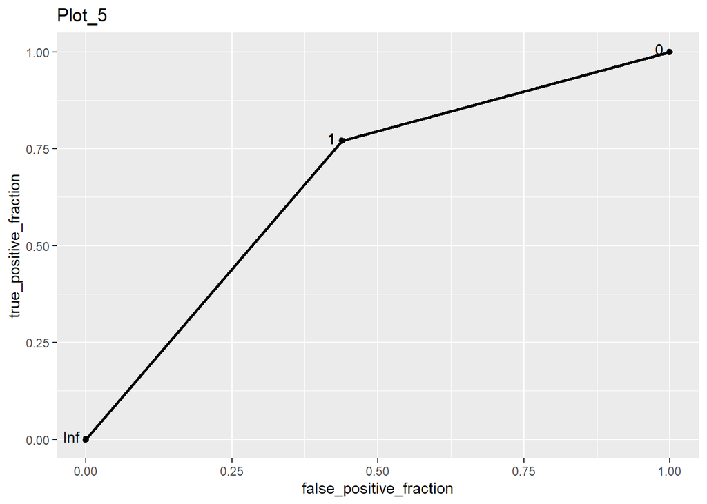

The sensitivity of the model is 77.01149 % and the specificity is 56.14035 % The AUC is 0.6657592. Using the testing/training set increased the AUC but produced very similar results.

## PCA and Clustering

```
## Standard deviations (1, .., p=3):
## [1] 1.3953031 0.8391102 0.5907821
##
## Rotation (n x k) = (3 x 3):
##                         PC1        PC2        PC3
## AnnouncementsView 0.6272915 -0.2502233  0.7374915
## Discussion        0.4926423  0.8609259 -0.1269256
## raisedhands       0.6031658 -0.4429389 -0.6633221
```

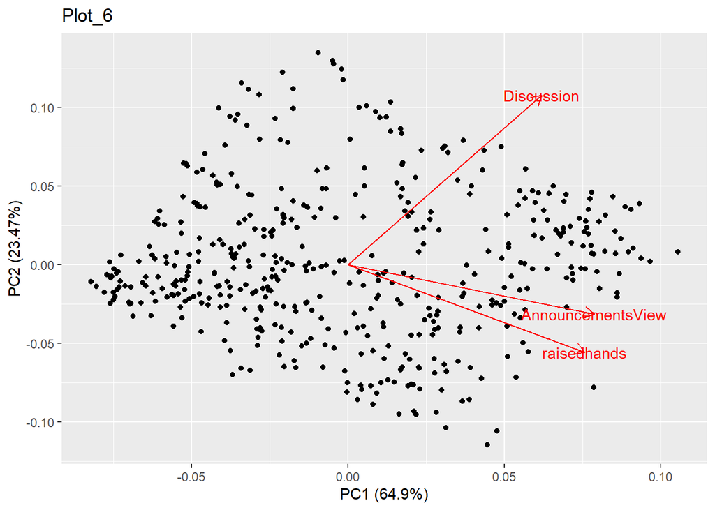

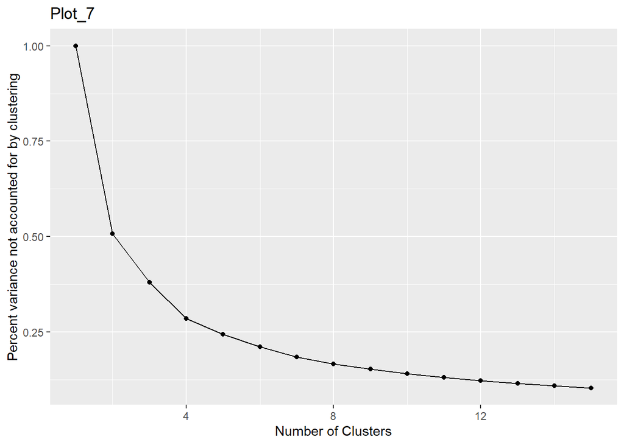

The elbow plot appears to start its linear decent somewhere between 5 and 2 clusters. This is indicative of the number of k-means clusters. Based upon the fact that the higher number of clusters makes it too hard to interpret graphically I decided to settle with 3 clusters.

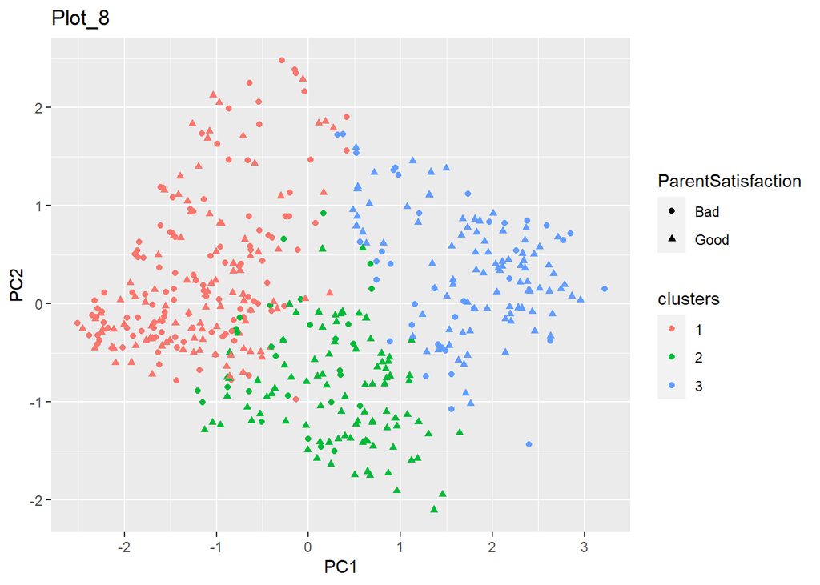

Through graphical examination it does appear that clusters are somewhat predictive of my binary feature of Parent Satisfaction. Clusters 3 and 1 definitely contain mainly ‘Good’ or ‘Bad’ while the center cluster 2 appears to be mainly ‘Good’ but with more ‘Bad’ mixed in then cluster 3. I suspect that ‘Class’ would be predicted much more effectively by the clusters then parent satisfaction.

## Logistic Regression with the Principle Componets.

```
##
## Call:
## glm(formula = Satisfaction ~ PC1 + PC2, family = binomial, data = data_train2)
##
## Deviance Residuals:
##     Min       1Q   Median       3Q      Max
## -2.1549  -1.1322   0.6617   0.9636   1.5838
##
## Coefficients:
##             Estimate Std. Error z value Pr(>|z|)
## (Intercept)   0.4902     0.1198   4.093 4.26e-05 ***
## PC1           0.4580     0.0911   5.028 4.97e-07 ***
## PC2          -0.4388     0.1492  -2.941  0.00327 **
## ---
## Signif. codes:  0 '***' 0.001 '**' 0.01 '*' 0.05 '.' 0.1 ' ' 1
##
## (Dispersion parameter for binomial family taken to be 1)
##
##     Null deviance: 449.36  on 335  degrees of freedom
## Residual deviance: 412.14  on 333  degrees of freedom
## AIC: 418.14
##
## Number of Fisher Scoring iterations: 4
```

```
##          n
## 1 78.16092
```

```
##          n
## 1 54.38596
```

```
##   PANEL group       AUC
## 1     1    -1 0.6627344
```

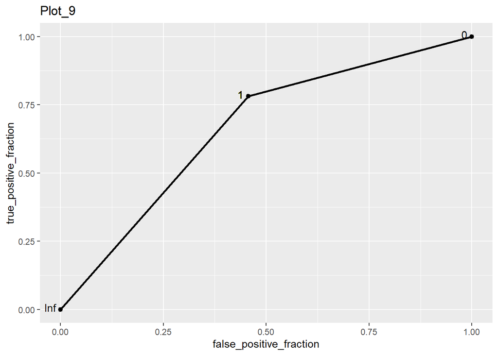

```
## [1] "2022-12-13 17:40:17 CST"
```

```
##        sysname        release        version       nodename        machine
##      "Windows"       "10 x64"  "build 19044" "KELLERONFIRE"       "x86-64"
##          login           user effective_user
##        "charl"        "charl"        "charl"
```